# Costs and Barriers to Home Ownership along

## the Mortgage Application Timeline

##### Author: Kathryn Hurchla for Data Design Dimension (c) 2021

exploratory data analysis for Design Labs: Industry Challenge, MICA Data Analytics & Visualization 9/28/2021

## Key Questions

- Where do folks exit the home loan application process?
- How do loan costs look at that point?
- Which loans are closing and which are not?
- How prevalent are negatively amortizing loans?
- What is the volume of loans of modest prices for new construction, in relation to higher priced loans and other homes of modest loan prices?

### Having to Do with the False Claims Act (FCA)

- How prevalent are "credit overlays" in FHA loans?
- To what degree do FHA loans incur higher initial fees than non-FHA loans, as a lenders' step to avoid or curb losses from liabilities with the FCA?

### Primary Data Source

#### Housing Mortgage Disclosure Act (HMDA) Modified Loan Application Registrat (LAR), FFIEC

https://ffiec.cfpb.gov/data-publication/

```python
# Import the necessaries libraries
# I will use matplotlib and seaborn for plots
import matplotlib.pyplot as plt
from matplotlib.sankey import Sankey
import seaborn as sns
# commented out because plotly was taking too long to render plots with this dataset
# import plotly.express as px
import pandas as pd
# commented out because I will use a downloaded data file
# if accessing data through API, import
# import requests
# commented out because I will use a CSV format data file
# import json # if working with dataset in JSON format from API or by downloading it in that format
```

```python
from IPython.core.interactiveshell import InteractiveShell
InteractiveShell.ast_node_interactivity = 'all'
```

### Load the Data

Load the dataset on the most recent 2020 year available of HMDA LAR

```python
# If calling dataset directly via the API using requests to JSON format
#view the docs at https://cfpb.github.io/hmda-platform/#hmda-api-documentation

#commented out this section because I ran up against 404 errors and was unable to load the large dataset.
#API call would need to have further troubleshooting to pursue

# # GET the data into a request object r
# # and tell Requests to stop waiting for a response after a given number of seconds with the timeout parameter.
# # failure to do so can cause a program to hang indefinitely
# r = requests.get("https://ffiec.cfpb.gov/v2/data-browser-api/view/nationwide/aggregations/?years=2018,2019,2020", timeout=0.10)

# # # view the response status code
# r.status_code
# # # check if this is an ok code
# r.status_code == requests.codes.ok
# # # check that the request is successful or view errors
# # r.raise_for_status#()

# # # use the built-in JSON decoder to read the API response
# # r.json()

# # # try to pretty print it if that's not done by default
# # print(r.json())#sort_keys=True, indent=4))
```

```python
# # If using JSON from API or download, load the json into a pandas dataframe
# # example for simple flattened json: df = pd.read_json('data/simple.json')
# df_hmdalar_2020 = pd.read_json('r/simple.json')
# # example for nested json: df = pd.read_json('data/nested_list.json')
# df_hmdalar_2020 = pd.read_json('r/nested_list.json')
```

```python
# If a CSV file is already downloaded from the Urban Data Catalog, and saved locally
# This was too large to load, and encountered mixed data types.
#df_2020 = pd.read_csv("../data/hmda_ffiec_nationwide.csv")#, low_memory=False)

# I downloaded a new file filtered for 2020, Loan_Purpose='Home Purchase', Total_Units=1 to limit the size and scope
#Attempted load with low memory off due to: DtypeWarning: Columns (5,22,23,24,26,27,28,29,30,31,32,33,38,44,46) have mixed types.Specify dtype option on import or set low_memory=False.
df_2020_single_purch = pd.read_csv("../data/hmda_ffiec_nationwide_2020_one-unit_home_purchase.csv", low_memory=False)
```

### Review the data

```python
# shape  of the dataframe in row and column counts
df_2020_single_purch.shape
```

```
(8185221, 99)
```

```python
# view the data types of all columns
df_2020_single_purch.info(verbose=True)
```

```
<class 'pandas.core.frame.DataFrame'>
RangeIndex: 8185221 entries, 0 to 8185220
Data columns (total 99 columns):
 #   Column                                    Dtype
---  ------                                    -----
 0   activity_year                             int64
 1   lei                                       object
 2   derived_msa-md                            int64
 3   state_code                                object
 4   county_code                               float64
 5   census_tract                              object
 6   conforming_loan_limit                     object
 7   derived_loan_product_type                 object
 8   derived_dwelling_category                 object
 9   derived_ethnicity                         object
```

[output cut: 91 more lines]

```python
# view the first five rows for a quick glance
df_2020_single_purch.head()
```

|  | activity_year | lei | derived_msa-md | state_code | county_code | census_tract | conforming_loan_limit | derived_loan_product_type | derived_dwelling_category | derived_ethnicity | ... | denial_reason-2 | denial_reason-3 | denial_reason-4 | tract_population | tract_minority_population_percent | ffiec_msa_md_median_family_income | tract_to_msa_income_percentage | tract_owner_occupied_units | tract_one_to_four_family_homes | tract_median_age_of_housing_units |
| --- | --- | --- | --- | --- | --- | --- | --- | --- | --- | --- | --- | --- | --- | --- | --- | --- | --- | --- | --- | --- | --- |
| 0 | 2020 | 549300E2UX99HKDBR481 | 36740 | FL | 12095.0 | 12095015004 | C | FHA:First Lien | Single Family (1-4 Units):Site-Built | Hispanic or Latino | ... | NaN | NaN | NaN | 8964 | 53.29 | 68100 | 127 | 2379 | 2944 | 20 |
| 1 | 2020 | 549300E2UX99HKDBR481 | 21340 | TX | 48141.0 | 48141010342 | C | FHA:First Lien | Single Family (1-4 Units):Site-Built | Hispanic or Latino | ... | NaN | NaN | NaN | 14761 | 91.88 | 52500 | 139 | 3439 | 4222 | 9 |
| 2 | 2020 | 549300E2UX99HKDBR481 | 36740 | FL | 12069.0 | 12069031203 | C | Conventional:First Lien | Single Family (1-4 Units):Site-Built | Ethnicity Not Available | ... | NaN | NaN | NaN | 6432 | 36.07 | 68100 | 91 | 2173 | 2597 | 14 |
| 3 | 2020 | 549300E2UX99HKDBR481 | 33460 | MN | 27139.0 | 27139080100 | C | FHA:First Lien | Single Family (1-4 Units):Site-Built | Not Hispanic or Latino | ... | NaN | NaN | NaN | 2131 | 35.66 | 97300 | 68 | 425 | 560 | 35 |
| 4 | 2020 | 549300E2UX99HKDBR481 | 15980 | FL | 12071.0 | 12071040114 | C | Conventional:First Lien | Single Family (1-4 Units):Site-Built | Not Hispanic or Latino | ... | NaN | NaN | NaN | 4396 | 7.03 | 68700 | 184 | 1884 | 2588 | 12 |

5 rows × 99 columns

```python
# see some summaries of the numerical variables
df_2020_single_purch.describe()
```

|  | activity_year | derived_msa-md | county_code | action_taken | purchaser_type | preapproval | loan_type | loan_purpose | lien_status | reverse_mortgage | ... | denial_reason-2 | denial_reason-3 | denial_reason-4 | tract_population | tract_minority_population_percent | ffiec_msa_md_median_family_income | tract_to_msa_income_percentage | tract_owner_occupied_units | tract_one_to_four_family_homes | tract_median_age_of_housing_units |
| --- | --- | --- | --- | --- | --- | --- | --- | --- | --- | --- | --- | --- | --- | --- | --- | --- | --- | --- | --- | --- | --- |
| count | 8185221.0 | 8.185221e+06 | 7.938501e+06 | 8.185221e+06 | 8.185221e+06 | 8.185221e+06 | 8.185221e+06 | 8185221.0 | 8.185221e+06 | 8.185221e+06 | ... | 194196.000000 | 29810.000000 | 2627.00000 | 8.185221e+06 | 8.185221e+06 | 8.185221e+06 | 8.185221e+06 | 8.185221e+06 | 8.185221e+06 | 8.185221e+06 |
| mean | 2020.0 | 3.708429e+04 | 2.819615e+04 | 2.483490e+00 | 6.648606e+00 | 1.955983e+00 | 1.457178e+00 | 1.0 | 1.027107e+00 | 2.661000e+01 | ... | 4.475535 | 5.652063 | 6.35630 | 5.626801e+03 | 2.986405e+01 | 7.699647e+04 | 1.097086e+02 | 1.462041e+03 | 2.012761e+03 | 3.245863e+01 |
| std | 0.0 | 2.544826e+04 | 1.663151e+04 | 1.980915e+00 | 1.818489e+01 | 2.051327e-01 | 7.755311e-01 | 0.0 | 1.623950e-01 | 1.633627e+02 | ... | 2.865795 | 2.408005 | 2.49115 | 3.474486e+03 | 2.494631e+01 | 2.158826e+04 | 4.537464e+01 | 9.583330e+02 | 1.210808e+03 | 1.801450e+01 |
| min | 2020.0 | 0.000000e+00 | 1.001000e+03 | 1.000000e+00 | 0.000000e+00 | 1.000000e+00 | 1.000000e+00 | 1.0 | 1.000000e+00 | 1.000000e+00 | ... | 1.000000 | 1.000000 | 1.00000 | 0.000000e+00 | 0.000000e+00 | 0.000000e+00 | 0.000000e+00 | 0.000000e+00 | 0.000000e+00 | -1.000000e+00 |
| 25% | 2020.0 | 1.943000e+04 | 1.210100e+04 | 1.000000e+00 | 0.000000e+00 | 2.000000e+00 | 1.000000e+00 | 1.0 | 1.000000e+00 | 2.000000e+00 | ... | 2.000000 | 5.000000 | 5.00000 | 3.694000e+03 | 1.028000e+01 | 6.780000e+04 | 8.500000e+01 | 9.040000e+02 | 1.322000e+03 | 1.900000e+01 |
| 50% | 2020.0 | 3.346000e+04 | 2.713700e+04 | 1.000000e+00 | 1.000000e+00 | 2.000000e+00 | 1.000000e+00 | 1.0 | 1.000000e+00 | 2.000000e+00 | ... | 4.000000 | 5.000000 | 6.00000 | 5.121000e+03 | 2.248000e+01 | 7.730000e+04 | 1.070000e+02 | 1.329000e+03 | 1.843000e+03 | 3.100000e+01 |
| 75% | 2020.0 | 4.174000e+04 | 4.501500e+04 | 4.000000e+00 | 3.000000e+00 | 2.000000e+00 | 2.000000e+00 | 1.0 | 1.000000e+00 | 2.000000e+00 | ... | 6.000000 | 9.000000 | 9.00000 | 6.846000e+03 | 4.339000e+01 | 8.620000e+04 | 1.330000e+02 | 1.837000e+03 | 2.492000e+03 | 4.300000e+01 |
| max | 2020.0 | 9.999900e+04 | 7.803000e+04 | 8.000000e+00 | 7.200000e+01 | 2.000000e+00 | 4.000000e+00 | 1.0 | 2.000000e+00 | 1.111000e+03 | ... | 9.000000 | 9.000000 | 9.00000 | 5.381200e+04 | 1.000000e+02 | 1.593000e+05 | 5.070000e+02 | 1.952900e+04 | 2.539100e+04 | 7.600000e+01 |

8 rows × 72 columns

### Now let's plot some data!

#### First an overall styling can be set for all the plots

```python
# # set seaborn style see docs for options https://seaborn.pydata.org/generated/seaborn.set_style.html?highlight=set_style
# sns.set_style('ticks')
# # set seaborn context; choose from 'paper','notebook','talk','poster'
sns.set_context('talk')
# # set a qualitative Color Brewer palette
# sns.set_palette('viridis_r')
# # take a peek at the palette
# sns.color_palette('viridis_r')
```

### Where do folks exit the home loan application process?

```python
# to chunk the reported loan records into fewer groups along the lifecycle of an appliation,
# create a group field based on action_taken
# Method using replace
df_2020_single_purch['stage'] = df_2020_single_purch['action_taken'].replace(
    {1: 'Origination', # 1 - Loan originated
     8: 'Preapproval', # 8 - Preapproval request approved but not accepted
     7: 'Preapproval', # 7 - Preapproval request denied
     4: 'Underwriting', # 4 - Application withdrawn by applicant
     5: 'Underwriting', # 5 - File closed for incompleteness
     6: 'Decision',  # 6 - Purchased loan
     2: 'Decision', # 2 - Application approved but not accepted
     3: 'Decision'}); # 3 - Application denied
```

```python
# # make a matrix of just the variables for a sankey diagram with stage
# # for some reason this kept overwriting the stage fields all to Preapproval, maybe because it's an assigned field
# # assign the select columns
# col0 = df_2020_single_purch.loc[df_2020_single_purch['stage'] == 'Origination']
# col1 = df_2020_single_purch.loc[df_2020_single_purch['stage'] == 'Preapproval']
# col2 = df_2020_single_purch.loc[df_2020_single_purch['stage'] == 'Underwriting']
# col3 = df_2020_single_purch.loc[df_2020_single_purch['stage'] == 'Decision']
# # merge the columns
# # flow =list(zip(*[col1,col2]))
```

[output not shown]

```python
# check variables to plot for nulls
# make a boolean series to only shows rows with NaN values (instead of all rows showing True or False)
bool_series = pd.isnull(df_2020_single_purch['action_taken'])

# display filtered data
df_2020_single_purch[bool_series]
```

|  | activity_year | lei | derived_msa-md | state_code | county_code | census_tract | conforming_loan_limit | derived_loan_product_type | derived_dwelling_category | derived_ethnicity | ... | denial_reason-3 | denial_reason-4 | tract_population | tract_minority_population_percent | ffiec_msa_md_median_family_income | tract_to_msa_income_percentage | tract_owner_occupied_units | tract_one_to_four_family_homes | tract_median_age_of_housing_units | stage |
| --- | --- | --- | --- | --- | --- | --- | --- | --- | --- | --- | --- | --- | --- | --- | --- | --- | --- | --- | --- | --- | --- |

0 rows × 100 columns

```python
# check entire dataframe form rows with one or more null values
df_2020_single_purch.isnull()
```

|  | activity_year | lei | derived_msa-md | state_code | county_code | census_tract | conforming_loan_limit | derived_loan_product_type | derived_dwelling_category | derived_ethnicity | ... | denial_reason-3 | denial_reason-4 | tract_population | tract_minority_population_percent | ffiec_msa_md_median_family_income | tract_to_msa_income_percentage | tract_owner_occupied_units | tract_one_to_four_family_homes | tract_median_age_of_housing_units | stage |
| --- | --- | --- | --- | --- | --- | --- | --- | --- | --- | --- | --- | --- | --- | --- | --- | --- | --- | --- | --- | --- | --- |
| 0 | False | False | False | False | False | False | False | False | False | False | ... | True | True | False | False | False | False | False | False | False | False |
| 1 | False | False | False | False | False | False | False | False | False | False | ... | True | True | False | False | False | False | False | False | False | False |
| 2 | False | False | False | False | False | False | False | False | False | False | ... | True | True | False | False | False | False | False | False | False | False |
| 3 | False | False | False | False | False | False | False | False | False | False | ... | True | True | False | False | False | False | False | False | False | False |
| 4 | False | False | False | False | False | False | False | False | False | False | ... | True | True | False | False | False | False | False | False | False | False |
| ... | ... | ... | ... | ... | ... | ... | ... | ... | ... | ... | ... | ... | ... | ... | ... | ... | ... | ... | ... | ... | ... |
| 8185216 | False | False | False | False | False | False | False | False | False | False | ... | True | True | False | False | False | False | False | False | False | False |
| 8185217 | False | False | False | False | False | False | False | False | False | False | ... | True | True | False | False | False | False | False | False | False | False |
| 8185218 | False | False | False | False | False | False | False | False | False | False | ... | True | True | False | False | False | False | False | False | False | False |
| 8185219 | False | False | False | False | False | False | False | False | False | False | ... | True | True | False | False | False | False | False | False | False | False |
| 8185220 | False | False | False | False | False | False | False | False | False | False | ... | True | True | False | False | False | False | False | False | False | False |

8185221 rows × 100 columns

```python
# find total length of dataframe i.e. number of rows
index = df_2020_single_purch.index
number_of_rows = len(index)
```

```python
# make a matrix of just the variables for a sankey diagram with action_taken

# assign the select columns
# col0 = df_2020_single_purch.loc[df_2020_single_purch['action_taken'] == 1]
# col1 = df_2020_single_purch.loc[df_2020_single_purch['action_taken'] == 8]
# col2 = df_2020_single_purch.loc[df_2020_single_purch['action_taken'] == 7]
# col3 = df_2020_single_purch.loc[df_2020_single_purch['action_taken'] == 4]
# col4 = df_2020_single_purch.loc[df_2020_single_purch['action_taken'] == 5]
# col5 = df_2020_single_purch.loc[df_2020_single_purch['action_taken'] == 6]
# col6 = df_2020_single_purch.loc[df_2020_single_purch['action_taken'] == 2]
# col7 = df_2020_single_purch.loc[df_2020_single_purch['action_taken'] == 3]
# assign the select columns as percent
col0 = (len(df_2020_single_purch[df_2020_single_purch['action_taken'] == 1])/number_of_rows)*100
col1 = (len(df_2020_single_purch[df_2020_single_purch['action_taken'] == 8])/number_of_rows)*100
col2 = (len(df_2020_single_purch[df_2020_single_purch['action_taken'] == 7])/number_of_rows)*100
col3 = (len(df_2020_single_purch[df_2020_single_purch['action_taken'] == 4])/number_of_rows)*100
col4 = (len(df_2020_single_purch[df_2020_single_purch['action_taken'] == 5])/number_of_rows)*100
col5 = (len(df_2020_single_purch[df_2020_single_purch['action_taken'] == 6])/number_of_rows)*100
col6 = (len(df_2020_single_purch[df_2020_single_purch['action_taken'] == 2])/number_of_rows)*100
col7 = (len(df_2020_single_purch[df_2020_single_purch['action_taken'] == 3])/number_of_rows)*100
# merge the columns
# flow =list(zip(*[col1,col2]))
```

```python
test = col0 + col1 + col2 + col3 + col4 + col5 + col6 + col7
test
```

```
100.0
```

```python
cols0_7 = (col0 + col1 + col2 + col3 + col4 + col5 + col6 + col7) # Origination start
cols1_7 = (col1 + col2 + col3 + col4 + col5 + col6 + col7) # Preapproval
cols3_7 = (col3 + col4 + col5 + col6 + col7) # Underwriting
cols5_7 = (col5 + col6 + col7) # Underwriting
```

```python
# test that the inputs and outputs equal tht number of rows
test = col0_7 - col0 - col1 - col2 - col3 - col4 - col5 - col6 - col7
test == number_of_rows
number_of_rows - test
```

```
False
```

[output not shown]

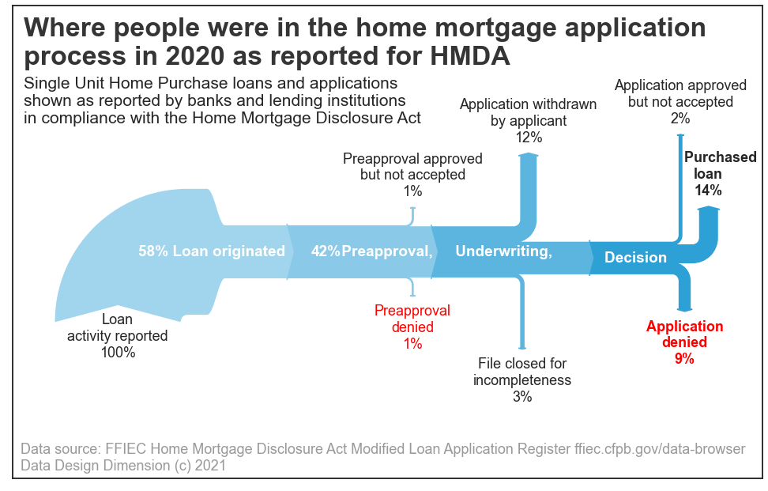

```python
# draw a sankey diagram of action_taken
fig = plt.figure(figsize = (17, 11))
# centered figure title
# fig.suptitle("Where people were in the mortgage application process\nin 2020 as reported for HMDA", fontsize=34, fontweight='bold', ha='center')
# instantiate an axes onto which the data should be plotted
ax = fig.add_subplot(1, 1, 1, xticks=[], yticks=[])#,
#                    title="Where people exited the mortgage application timeline") # another way to add a title
# place title inside plot area to upper left
ax.set_title("Where people were in the home mortgage application\nprocess in 2020 as reported for HMDA", x=0.015,  y=1.0, pad=-75, loc='left', fontsize=34, fontweight='bold', color='#353535')
# text to clarify dataset and context
ax.text(0.015, 0.85,
        'Single Unit Home Purchase loans and applications\nshown as reported by banks and lending institutions\nin compliance with the Home Mortgage Disclosure Act',
        verticalalignment='top',
        horizontalalignment='left',
        transform=ax.transAxes,
#         color='#353535',
        fontsize=21)

sankey = Sankey(ax=ax, scale=0.0175, offset=.445, head_angle=150, margin=0.6, tolerance=1e-06, format='%.0f', unit='%', gap=0.25)

# first diagram section from left to right
sankey.add(flows=[cols0_7, -(cols1_7)],
           labels=['Loan\nactivity reported', ''],
           orientations=[-1, 0],
           pathlengths=[0.1, 0.75],
           trunklength = 1,
           patchlabel="58% Loan originated  ", # Arguments to matplotlib.patches.PathPatch # left off as redundant
           edgecolor = '#A1D5ED',
           facecolor = '#A1D5ED'
           )

# second diagram section from left to right
sankey.add(flows=[cols1_7, -(col1), -(col2), -(cols3_7)],
           labels=[None,
                   'Preapproval approved\nbut not accepted', # 'Preapproval request approved\nbut not accepted'
                   'Preapproval\ndenied', # 'Preapproval request denied'
                   None],
           orientations=[0, 1, -1, 0],
           pathlengths=[1.0, 0.25, 0.25, 0.25],
           patchlabel="     Preapproval,", # Arguments to matplotlib.patches.PathPatch
           trunklength = 1,
           prior = 0, # which sankey are you connecting to (0-indexed being the first)
           connect = (1, 0), # which flow index number from the prior to connect to which flow index in this one (prior, this)
           edgecolor = '#8ACAE8',
           facecolor = '#8ACAE8'
           )

# third diagram section from left to right
sankey.add(flows=[cols3_7, -(col3), -(col4), -(cols5_7)],
           labels=[None,
                   'Application withdrawn\nby applicant',
                   'File closed for\nincompleteness',
                   None],
           orientations=[0, 1, -1, 0],
           pathlengths=[0.5, 1.0, 1.0, 0.75],
           patchlabel="         Underwriting,", # Arguments to matplotlib.patches.PathPatch
           trunklength = 1,
           prior = 1, # which sankey are you connecting to (0-indexed)
           connect = (3,0), # flow index number to connect: (prior, this)
           edgecolor = '#5BB5DF',
           facecolor = '#5BB5DF'
           )

# fourth diagram section from left to right
sankey.add(flows=[cols5_7, -(col6), -(col5), -(col7)],
           labels=[None,
                   'Application approved\nbut not accepted',
                   '      Purchased\nloan',
                   'Application\ndenied'],
           orientations=[0, 1, 1, -1],
           pathlengths=[0.75, 1.5, 0.5, 0.5],
           patchlabel="Decision        ", # Arguments to matplotlib.patches.PathPatch
           trunklength = 0.75,
           prior = 2, # which sankey are you connecting to (0-indexed)
           connect = (3, 0), # flow index number to connect: (prior, this)
           edgecolor = '#2DA0D6',
           facecolor = '#2DA0D6'
           )

diagrams = sankey.finish()
# emphasise the denails in red
diagrams[3].texts[-1].set_color('r')
diagrams[1].texts[-2].set_color('r')
# pop out all thelabels as bold to separate and offset them from the background text/title/context
diagrams[3].texts[-1].set_fontweight('bold')
diagrams[1].texts[-1].set_fontweight('bold')
diagrams[3].texts[-2].set_fontweight('bold')
#diagrams[2].texts[-2].set_color('black')
# bold the central stage flows for high level emphasis
diagrams[0].texts[1].set_fontweight('bold')
diagrams[0].text.set_fontweight('bold')
diagrams[1].text.set_fontweight('bold')
diagrams[2].text.set_fontweight('bold')
diagrams[3].text.set_fontweight('bold')
diagrams[0].texts[1].set_fontsize('19')
diagrams[0].text.set_fontsize('19')
diagrams[1].text.set_fontsize('19')
diagrams[2].text.set_fontsize('19')
diagrams[3].text.set_fontsize('19')
# make stage text white
diagrams[0].texts[1].set_color('white')
diagrams[0].text.set_color('white')
diagrams[1].text.set_color('white')
diagrams[2].text.set_color('white')
diagrams[3].text.set_color('white')
# handle scientific notation displayed by default, to show more natural numbers that are easy to understand
# plt.ticklabel_format(axis="y", style='plain'); # this was not working for the flow values before I changed to percentages

#add a footer for source
ax.text(0.01, 0.01,
        'Data source: FFIEC Home Mortgage Disclosure Act Modified Loan Application Register ffiec.cfpb.gov/data-browser\nData Design Dimension (c) 2021',
        verticalalignment='bottom',
        horizontalalignment='left',
        transform=ax.transAxes,
        color='#989B98',
        fontsize=18);
```

```python
# check the figure image stats
print('Figure dpi: ', fig.get_dpi())

# Find the Figure size in inches
print('\nFigure size (width, height):', fig.get_size_inches())

# Get the Figure width and height (inches)
print('\nFigure width:', fig.get_figwidth())
print('Figure height:', fig.get_figheight())

# Get the Figure width and height (pixels)
print('\nFigure pixel width:', fig.get_figwidth() * fig.get_dpi())
print('Figure pixel height:', fig.get_figheight() * fig.get_dpi())
```

```
Figure dpi:  72.0

Figure size (width, height): [17. 11.]

Figure width: 17.0
Figure height: 11.0

Figure pixel width: 1224.0
Figure pixel height: 792.0
```

```python
# save the figure as an image file
# with its white background
fig.savefig('../output/one_unit_home_mortgage_activity_flow_2020.jpeg', dpi=100, facecolor='auto', edgecolor='gray',
        orientation='landscape', format='jpeg',
        transparent=False, bbox_inches=None, pad_inches=0.1)

# with transparent background, to test an image behind in Illustrator
fig.savefig('../output/one_unit_home_mortgage_activity_flow_2020_transparent.jpeg', dpi=100, edgecolor='gray',
        orientation='landscape', format='jpeg',
        transparent=True, bbox_inches=None, pad_inches=0.1)
```

[figure not shown]

```python
# Sankey diagram with two systems example
fig = plt.figure()
ax = fig.add_subplot(1, 1, 1, xticks=[], yticks=[], title="Exit Here: the Mortgage Application Timeline")
flows = [0.25, 0.15, 0.60, -0.10, -0.05, -0.25, -0.15, -0.10, -0.35]
sankey = Sankey(ax=ax, unit=None)
sankey.add(flows=flows, label='En route',
           orientations=[-1, 1, 0, 1, 1, 1, -1, -1, 0])
sankey.add(flows=[-0.25, 0.15, 0.1], label='Exited',
           orientations=[-1, -1, -1], prior=0, connect=(0, 0))
diagrams = sankey.finish()
diagrams[-1].patch.set_hatch('/')
plt.legend();
```

```python
# # try a stacked bar chart
# # Instantiate a figure and
# fig = plt.figure()
# # a single Axes and groupby the negative amortization value then action taken
# # add a top grouping field to chunk these up into smaller timeline groups
# ax = df_2020_single_purch.groupby(['stage', 'action_taken']).size().unstack().plot(kind='bar', stacked=True, rot=1)

# # Add a title
# ax.set_title('Action Taken on the Loan or Application', size=24, y=1.10)

# # Label the x- and y-axis
# ax.set_xlabel('Action')
# # ax.set_ylabel('Count, size=12);

# # add a lengend
# plt.legend(df_2020_single_purch['action_taken'], 'upper right', shadow=True)
# # ax.legend(['Loan originated',
# #           'Application approved but not accepted',
# #           'Application denied',
# #           'Application withdrawn by applicant',
# #           'File closed for incompleteness',
# #           'Purchased loan',
# #           'Preapproval request denied',
# #           'Preapproval request approved but not accepted'],
# #            loc='upper right');

# # handle scientific notation displayed by default, to show more natural numbers that are easy to understand
# plt.ticklabel_format(axis="y", style='plain');
```

### Are negatively amortizing loans still occurring?

*inspired by the Brookings topic number 1, Ability to Repay and Fair Lending Rules, from its published Four Key Issues that Will Determine the Future of the Housing Market section* *Brookings Institute Lessons from the financial crisis [1]*

```python
# How does the data shake out for this piece of information across all single family loan applications?
df_2020_single_purch.negative_amortization.value_counts()
```

```
2       8000723
1111     182603
1          1895
Name: negative_amortization, dtype: int64
```

```python
# The variable was interpreted as an integer (int64) by default, but
# change it it a category dtype because it represents 3 distinct options according to the LAR data fields dictionary (https://ffiec.cfpb.gov/documentation/2019/lar-data-fields/)
# this will plot it more logically, since otherwise the values–1, 2, and 1111–would show in a wide numerical spread on y axis
df_2020_single_purch.negative_amortization = df_2020_single_purch.negative_amortization.astype('category')
```

*inspired by the Brookings topic number 2, Housing Supply, from its published Four Key Issues that Will Determine the Future of the Housing Market section* *Brookings Institute Lessons from the financial crisis [1]*

### False Claims Act impact on FHA lending

*inspired by the Brookings topic number 3, False Claims Act, from its published Four Key Issues that Will Determine the Future of the Housing Market section*

"In the FHA context, lenders are required to make certifications when they submit loans to FHA for insurance. These include statements that the loan complies with the FHA eligibility standards, which are quite extensive and leave little room for even clerical mistakes. The FCA does not require an intent to defraud, so these errors generate potential liability, even when they have little or no impact on the safety of the loan. And that potential liability is huge....

Lenders have paid billions of dollars to settle these claims brought by the Justice Department. As a result, lenders have taken several steps to avoid this liability. Some major lenders have exited FHA lending entirely. Many have added “credit overlays”- not making loans to lower credit score families, even though the loans are sound loans because they still have a higher risk of default and FCA liability only comes when a loan defaults. Others have added additional fees to the loans to try to offset the cost of this liability."

*Brookings Institute Lessons from the financial crisis [1]*

1. What major lenders (by size or # of loans) are not doing FHA loans?
   - Note showing whether they previously did FHA loans prior to housing crisis would require pre-2018 data.
2. How often are FHA loans declined due to low credit score?
   - By top 10 individual lending institutions in # of loans fitting this question
3. How do total fees compare for FHA loans to non-FHA loans?
   - Is there a pattern in fees by particular lending institutions fitting this question?

### Federal Support for Housing Finance and GSE loans

*inspired by the Brookings topic number 4, Housing Secondary Market Finance, from its published Four Key Issues that Will Determine the Future of the Housing Market section*

The Government-Sponsored Enterprises, namely Federal National Mortgage Association (Fannie Mae) and Federal Home Mortgage Corporation (Freddie Mac), back the most common loans, called GSE loans [2, 3]. During the housing crisis of 2007 and 2008, housing prices plummeted and more loans became delinquent or went into default when the borrowers were unable to pay. These GSEs lost billions of dollars, having a tremendous impact on markets, and were later fined millions of dollars for improper accounting and misstatements and problems in control and governance. [3]

1. Do GSE loans serve the broad group of qualified families who seek to become homeowners, , and not just serve the wealthiest and most profitable borrowers? [1]
   - How level is the pricing of the guarantee fees the GSE's charge, or total fees in absense of that variable?
2. Are GSE's fulfilling their explicitly duty to serve underserved markets? [1]
   - Can this be determined by census tracts or areas, and/or by race or ethnicity?

#### Quote to consider: growth of Latino families and the importance of affordable housing

"A healthy housing market, especially in the upcoming years, requires that this strong focus on affordable housing continues. ... Looking forward, the housing market is increasingly comprised of more families without as much intergenerational wealth. Households of color – especially Latino families – account for the largest growth in households today, making it increasingly important that they are served."

*Brookings Institute Lessons from the financial crisis [1]*

#### Quote to consider: noteworthy drill down story of ethical lenders

"Disparate impact analysis encourages creative approaches that both increase effectiveness and inclusiveness. This process and the value of disparate impact analysis was recently pointed out, and endorsed by, the largest personal loan company in the country, Lending Club, in its responses to requests for input by the CFPB.[28] Taking care to reach rapidly-growing markets of borrowers of color when structuring business practices is good business. And it is a false choice that inclusiveness is incompatible with growth and efficiency."

*Brookings Institute Lessons from the financial crisis [1]*

### Cited & Referenced

[1] Lessons from the financial crisis, by Michael Calhoun, Brookings Institute, 9/5/2018, https://www.brookings.edu/research/lessons-from-the-financial-crisis-the-central-importance-of-a-sustainable-affordable-and-inclusive-housing-market/

[2] Who is Involved with Mortgage Servicing?, Urban Institute, accessed 9/27/2021, https://www.urban.org/policy-centers/housing-finance-policy-center/projects/mortgage-servicing-collaborative/help-me-understand-mortgage-servicing/who-involved-mortgage-servicing

[3] A Brief History of the Housing Government-Sponsored Enterprises, Federal Home Finance Agency Office of Inspector General, accessed 9/27/2021, https://www.fhfaoig.gov/Content/Files/History%20of%20the%20Government%20Sponsored%20Enterprises.pdf

[4] The Trump Administration Plays its Last Cards on Fannie and Freddie (Brief), by Jim Parrott, Urban Institute, 1/15/2021, https://www.urban.org/research/publication/trump-administration-plays-its-last-cards-fannie-and-freddie